# COVID-19

```python
from scipy.optimize import curve_fit
from sklearn.linear_model import LogisticRegression
def modelo_logistico(x,a,b):
    return a+b*np.log(x)

exp_fit = curve_fit(modelo_logistico,x,y) #Extraemos los valores de los paramatros
exp_fit1 = curve_fit(modelo_logistico,x,z) #Extraemos los valores de los paramatros

print(exp_fit)
print("")
print(exp_fit1)
```

```
(array([-446.45387554,  253.81600502]), array([[104244.84312108, -22124.2513417 ],
       [-22124.2513417 ,   4907.61524206]]))

(array([-10481.82124408,   3486.39542592]), array([[ 604709.26516529, -128339.5842676 ],
       [-128339.5842676 ,   28468.36684504]]))
```

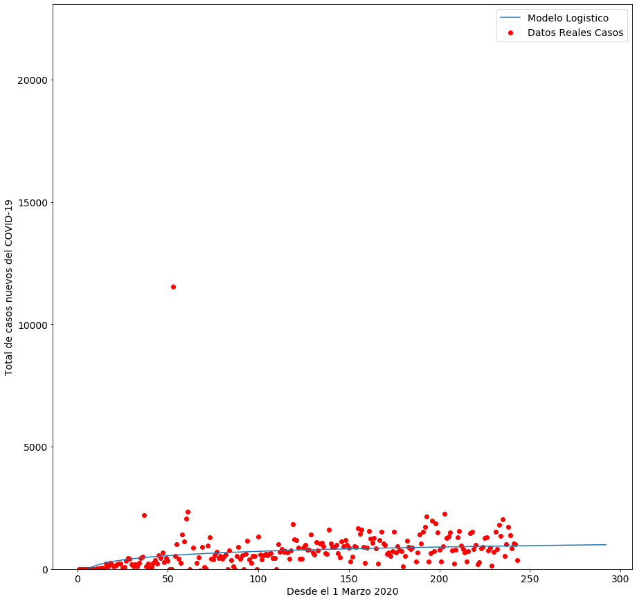

```python
pred_x = list(range(min(x),max(x)+50)) # Predecir 50 dias mas
plt.rcParams['figure.figsize'] = [15, 15]
plt.rc('font', size=14)
# Real data
plt.scatter(x,y,label="Datos Reales Casos",color="red")
# Predicted exponential curve
plt.plot(pred_x, [modelo_logistico(i,exp_fit[0][0],exp_fit[0][1]) for i in pred_x], label="Modelo Logistico" )
plt.legend()
plt.xlabel("Desde el 1 Marzo 2020")
plt.ylabel("Total de casos nuevos del COVID-19")
plt.ylim(0,max(y)*2) # Definir los limites de Y
plt.show()
```

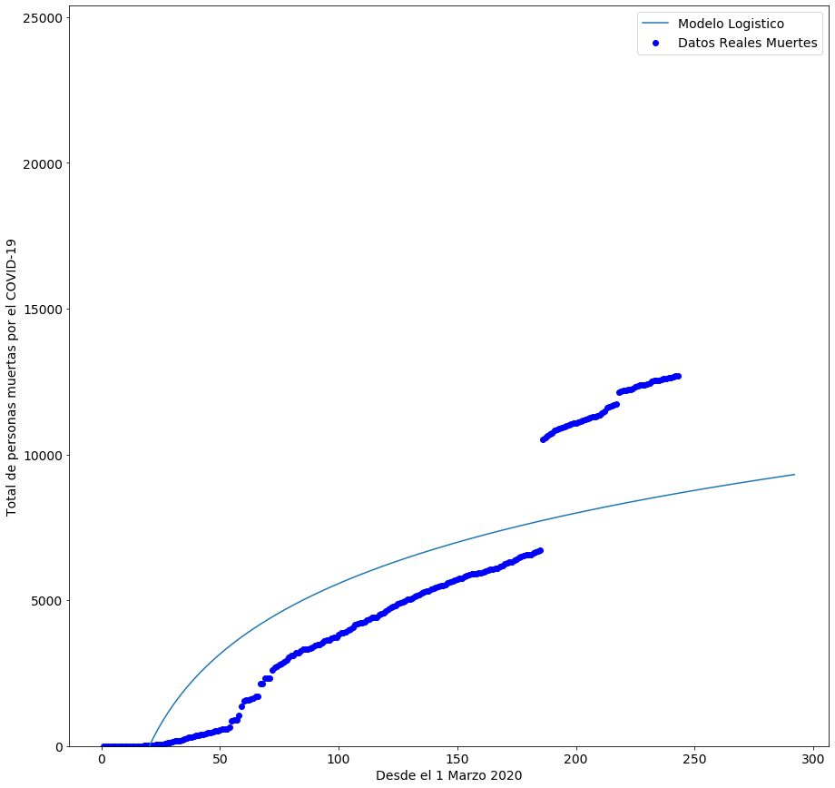

```python
plt.scatter(x,z,label="Datos Reales Muertes",color="blue")
plt.plot(pred_x, [modelo_logistico(i,exp_fit1[0][0],exp_fit1[0][1]) for i in pred_x], label="Modelo Logistico" )
plt.legend()
plt.xlabel("Desde el 1 Marzo 2020")
plt.ylabel("Total de personas muertas por el COVID-19")
plt.ylim(0,max(z)*2)
plt.show()
```

## Interpretación

En esta etapa del estudio, se interpreta los resultados que arrojan la simulación y en base a esto se toma una decisión. Es obvio que los resultados que se obtiene de un estudio de simulación ayudan a soportar decisiones del tipo semi-estructurado.

## Implementación

Se entrega la solución al cliente y se lo capacita en su uso.

## Documentación

Dos tipos de documentación son requeridos para hacer un mejor uso del modelo de simulación. La primera se requiere a la documentación del tipo técnico, es decir, a la documentación que el departamento de procesamiento de datos debe tener del modelo. La segunda se refiere al manual de usuario, con el cual se facilita la interacci0n y el uso del modelo desarrollado, a través de una terminal de computadora.

#### Referencias

https://computacion-de-sistemas.es.tl/1-.-6-.-_Etapas-de-un-Proyecto-de-Simulaci%F3n.htm

https://es.slideshare.net/GOGA81/exposicion-del-simulacion-38382231#:~:text=Formulaci%C3%B3n%20del%20modelo%20%EF%82%97%20La,los%20par%C3%A1metros%20de%20las%20variables.&text=Es%20necesario%20estimar%20los%20valores,de%20las%20distribuciones%20de%20probabilidad.